# Sistemas estocásticos de series cronológicas lineales y no lineales

2019-09-25

## Introducción

- Serie cronológica: Información obtenida de manera secuencial a o largo del tiempo.
  - Finanzas: Devaluación del colón, exportaciones.
  - Demografía: Mortalidad, fecundidad, migración.
  - Actuarial: Moralidad para sostenibilidad del sistema de pensiones.
- Al trabajar series cronológicas se busca:
  - Análisis exploratorios de los datos (ccrecimiento o decrecimiento, valors atípicos, nivel medio).
  - Generación de modelos para simplificar la realidad del fenómeno.
  - **Obtener pronósticos para los valores futuros**.
- Los tres puntos anteriores se trabajan de manera secuencial, pero obtener un modelo adecuado es fundamental.

## Introducción

- Modelos clásicos:
  - Regresión lineal.
  - Suavizamiento exponencial.
  - **Modelos ARIMA**
- Los modelos ARIMA:
  - Asumen **linealidad** y **estacionariedad.**
  - No supone ningún patrón en particular en la serie histórica que se busca pronosticar, sino que contempla un proceso iterativo para identificar un posible modelo a partir de una clase general de modelos y luego someter dicho modelo a diferentes pruebas y medidas de rendimiento para evaluar su ajuste.
  - Requiere indentificar el proceso \(ARIMA(p,d,q)(P,D,Q)_S\) que gobierna la serie cronológica.
- Métodos de identificación del modelo:
  - Visual.
  - Pruebas estadísticas.
  - Procesos automáticos o semiautomáticos.

## Aporte metodológico

Mediante un estudio de simulación, desarrollar un método para la generación semiautomática de modelos de series cronológicas con el fin de generar pronósticos adecuados para la misma.

## Objetivos

- Objetivo general:
  - Evaluar la calidad de los pronósticos realizados con un método semiautomático para la estimación de modelos frecuentistas de series cronológicas lineales o no lineales, y estacionarias o no estacionarias.
- Objetivos específicos:
  - Diseñar un algoritmo para la selección de un modelo de series cronológicas según la temporalidad de la serie.
  - Aplicar validación cruzada en distintos horizontes de pronóstico para identificar la mejor especificación de un modelo de series cronológicas.
  - Comparar la precisión de los pronósticos con métodos automáticos similares, como el propuesto por Rob J. Hyndman.
  - Integrar la metodología de análisis de series temporales en una librería del lenguaje estadístico R.

## Metodología

```r
simular.proceso <- function(data, n, temporalidad, no.estacional, estacional,
                            p=NULL, q=NULL, P=NULL, Q=NULL){

    require(forecast)
    coeficientes <- list(p, q, P, Q)
    coeficientes.simulados <- lapply(c(no.estacional[c(1,3)], estacional[c(1,3)]),
                                     function(x) sample(seq(-1,1,.1), x))
    pos <- which(sapply(coeficientes, is.null)==TRUE)

    coeficientes[pos] <- coeficientes.simulados[pos]
    names(coeficientes) <- c("p", "q", "P", "Q")

    modelo <- Arima(ts(data=data, freq=temporalidad),
                    order = no.estacional,
                    seasonal = estacional,
                    fixed=c(phi=coeficientes$p,
                            theta=coeficientes$q,
                            Phi=coeficientes$P,
                            Theta=coeficientes$Q))
    datos <- simulate(modelo, nsim=n)
    list(modelo=modelo, datos=datos)
}
```

## Metodología (simulación)

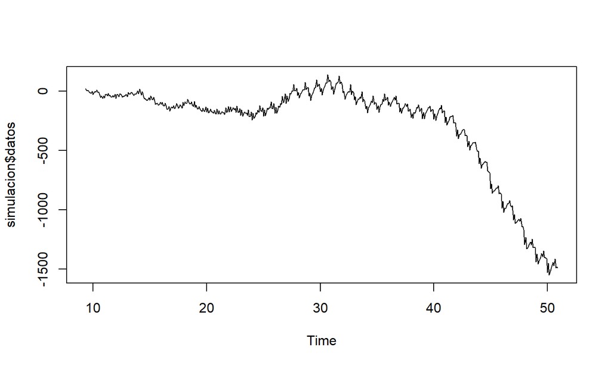

```r
set.seed(1)
simulacion <- simular.proceso(data=rpois(100, 15), n=500, temporalidad=12, no.estacional=c(1,1,3), estacional = c(2,1,1), p=.1)
plot(simulacion$datos, type="l")
```

## Metodología (sobreparametrización)

```r
modelo.arima <- function(serie, no.estacional, estacional, regr = NULL){
if(is.null(regr)){
    modelo <- tryCatch({
      forecast::Arima(serie, order = no.estacional, seasonal = estacional)
    },
    error = function(e) NULL)
  }

  if(!is.null(regr)){
    modelo <-tryCatch({
      forecast::Arima(serie, order = no.estacional, seasonal = estacional,
                      xreg = regr)
    },
    error = function(e) NULL)
  }

  if(!is.null(modelo)){
    grados.libertad <- modelo$nobs - length(modelo$coef)
    t.value <- modelo$coef/sqrt(diag(modelo$var.coef))
    prob <- stats::pf(t.value^2, df1 = 1, df2 = grados.libertad, lower.tail = FALSE)
    ifelse(sum(1*prob>0.05)<1, return(modelo), 1)
  }
}
```

## Metodología (medidas de rendimiento)

```r
medidas.arima <- function(modelo, testing, horizonte, regr = NULL){
  ##Nombre del modelo
  nombre <- capture.output(modelo)
  nombre <- substr(nombre[2],1, 23)
  ##Criterios de informacion
  data <- capture.output(summary(modelo))
  data <- data[grepl("AIC", data) == T]
  informacion <- strsplit(data, " ")
  pos <- which(sapply(informacion, nchar)>0)
  informacion <- informacion[[1]][pos]
  informacion <- do.call("rbind", strsplit(informacion, "=")) %>%
    data.frame()
  colnames(informacion) <- c("Medida", "Valor")
  informacion <- informacion %>%
    mutate(Valor = as.numeric(as.character(Valor))) %>%
    spread(Medida, Valor) %>%
    data.frame(Modelo = nombre)
  ##Medidas de rendimiento
  rendimiento <- data.frame(Modelo = c(nombre, paste(nombre, "Validacion")),
                            accuracy(forecast(modelo, horizonte, xreg = regr), testing))
  merge(informacion, rendimiento, by="Modelo", all = TRUE) %>%
    dplyr::select(Modelo, AIC, AICc, BIC, MAE, MAPE, RMSE, MASE)
}
```

## Metodología (evaluación automática)

```r
arimas.auto <- function(tipo = c(p = 1, d = 1, q = 1,
                                 P = 1, D = 1, Q = 1),
                        serie, reg = NULL, validacion, horiz = 12,
                        paralelo=FALSE, clusters=detectCores(logical = FALSE)){
  #Matriz para la identificacion de los parametros del modelo
  valores <- expand.grid(p = 0:tipo[1], d = 0:tipo[2], q = 0:tipo[3],
                         P = 0:tipo[4], D = 0:tipo[5], Q = 0:tipo[6])
  valores.no.estacional <- split(as.matrix(valores[, 1:3]), row(valores[, 1:3]))
  valores.estacional <- split(as.matrix(valores[, 4:6]), row(valores[, 4:6]))
  #Estimación de los modelos
  if(paralelo==FALSE){
    modelos <- mapply(modelo.arima, no.estacional=valores.no.estacional,
                      estacional=valores.estacional, MoreArgs = list(serie=serie, regr=reg),
                      SIMPLIFY = FALSE)
  }
  if(paralelo==TRUE){
    #Nombres de los objetos a exportar a cada cluster
    obj <- sapply(as.list(match.call()), paste)
    pos <- which(names(obj) %in% c("serie", "validacion"))
    #Generar los cluster
    clp <- makeCluster(clusters, type = "SOCK", useXDR=FALSE)
    clusterExport(clp, varlist = c(obj[pos], "medidas.arima", "modelo.arima"))
    #Proceso en paralelo
    modelos <- clusterMap(cl=clp, fun = modelo.arima,
                       no.estacional=valores.no.estacional,
                       estacional=valores.estacional,
                       MoreArgs = list(serie=serie, regr=reg),
                       SIMPLIFY = FALSE, .scheduling = "dynamic")
    stopCluster(clp)
  }
  #Obtiene las posiciones de la lista donde se pudieron estimar los modelos
  pos <- which(sapply(sapply(modelos, class), length)>1)
  #Calcula las medidas de rendimiento y los criterios de información
  medidas <- do.call("rbind", lapply(modelos[pos],
                                     medidas.arima,
                                     testing = validacion,
                                    horizonte= horiz,
                                     regr = reg)) %>%
    mutate_if(is.numeric, round, 2)
  #Devuelve una lista con los modelos y las medidas de rendimiento
  list(modelos=modelos[pos], medidas=medidas)
}
```

## Metodología (mejores arimas)

```r
mejores.arimas <- function(tabla, peso.train=.3, peso.test=.7){
  #Elimina posibles modelos duplicados
  tabla <- tabla %>%
    distinct(Modelo, .keep_all = TRUE)
  #Crea variable para agrupar modelos en train y test
  tabla <- tabla %>%
    mutate(mod = as.character(c(0, rep(1:(nrow(tabla)-1)%/%2))))
  #Crea la variable de puntaje ponderado
  tabla2 <- tabla %>%
    mutate_at(vars(contains("C")), function(x){x-min(x, na.rm=TRUE)}) %>%
    mutate_if(is.numeric, function(x) ifelse(is.na(x),0,x)) %>%
    mutate(puntaje = AIC+AICc+BIC+MAE+MAPE+RMSE+MASE,
           ponde = ifelse(grepl("Validacion", Modelo)==TRUE, peso.test, peso.train),
           puntaje = puntaje*ponde)
  #Busca el(los) puntaje(s) mínimo(s)
  puntaje.minimo <- tabla2 %>%
    group_by(mod) %>%
    summarise(puntaje=sum(puntaje))
  #Obtiene la(s) posición(es) con puntaje(s) más bajo(s)
  pos <- puntaje.minimo$mod[which(puntaje.minimo$puntaje==min(puntaje.minimo$puntaje))]
  #Devuelve el(los) mejor(es) modelo(s)
  tabla %>%
    filter(mod %in% pos) %>%
    dplyr::select(Modelo:MASE)
}
```

## Metodología (comparación)

```r
comparacion <- function(data, prop, proceso){
    require(parallel)
    require(tidyr)
    require(dplyr)
    corte <- round(length(data)*prop, 0)
    train <<- subset(data, end=corte)
    test <<- subset(data, start=corte+1)
    hyndman <- auto.arima(train)
    gamboa <- arimas.auto(tipo=proceso, serie=train, validacion=test, paralelo=TRUE)
    gamboa <- mejores.arimas(gamboa$medidas)
    list(hyndman=hyndman, gamboa=gamboa)
}

k <- comparacion(data=simulacion$datos, prop=.8,
                 proceso=c(3,1,3,3,1,3))
```

## Resultados

```r
k$gamboa
```

```
##                               Modelo     AIC    AICc     BIC  MAE  MAPE
## 1            ARIMA(0,1,3)(1,1,0)[12] 2817.18 2817.34 2836.97 6.99 23.06
## 2 ARIMA(0,1,3)(1,1,0)[12] Validacion      NA      NA      NA 6.10  1.49
##   RMSE MASE
## 1 8.91 0.21
## 2 8.71 0.18
```

```r
mod <- Arima(train, order=c(0,1,3), seasonal=c(1,1,0))
```

## Resultados

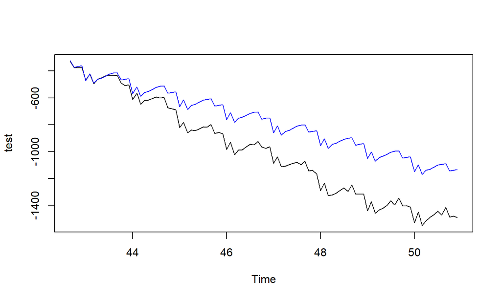

```r
plot(test, type="l")
lines(forecast(mod, h=100)$mean, col="blue")
```

## Siguientes pasos

- Mejorar el metodo de estiamción de los ARIMA.
  - Intervenciones.
  - Deteccción de cambipos de nivel.
  - Medidas para la selección edl modelo.
- Incorporar métodos no lineales:
  - Modelos Umbral (”Threshold Models”).
  - Modelos EXPAR (”Amplitude-dependent exponential autoregressive models”).
  - Modelos EXPAR (”Amplitude-dependent exponential autoregressive models”).
  - Modelos FAR (”Fractional autoregressive models”).
  - Modelos PAR (”Product autoregressive models”).
  - Modelos RCA (”Random coefficient autoregressive models”).
  - Modelos NEAR (”Newer exponential autoregressive models”).
  - Modelos autoregresivos con espacio de estados discreto.
  - Modelos bilineales (BL).
  - Modelos no lineales de medias móviles.
  - Modelos ARCH (”Autoregressive models with conditional heterocedasticity”).
  - Modelos de segunda generación.
  - Modelos doblemente estocásticos.
  - Modelos SDM (”State dependent models”) o dependientes de estados.